# Lab 3: Exploratory Data Analysis

BMI 206

Isobel Beasley

8th November 2024

**Prepare the data.**

The data used in this exercise was generated by performing whole genome sequencing analysis of metastatic prostate tumors. This assay allows us to identify structural variations in tumor genomes such as duplications, inversions, and large deletions.

For more details on the analysis and results, see [Quigley et al. Cell 2018](https://pubmed.ncbi.nlm.nih.gov/30033370).

We counted the number of structural variations in each tumor sample. For our purposes, variants come in five types: inversions, deletions, duplications, insertions, and translocations. We also assessed each biopsy to identify biallelic inactivating mutations in each gene. Read in summaries of the number of structural variants present in each tumor and the presence/absence of mutations for a few selected genes.

```r
# Change working_folder to the path where the files are located
#working_folder = '/notebook/talks/2022_10_BMS_EDA/EDA'
fn_sum = here::here("eda/SV_summary_table.txt") #paste0( working_folder, '/SV_summary_table.txt' )
fn_mut = here::here("eda/WCDT_mutations.txt") #paste0( working_folder, '/WCDT_mutations.txt')
sv = read.table(fn_sum, sep='\t', header=TRUE, stringsAsFactors=FALSE)

mut = read.table(fn_mut, sep='\t', header=TRUE, stringsAsFactors=FALSE)

# if you don't have ggplot2 or reshape2 installed, un-comment and run the next two lines:
#install.packages("ggplot2")
#install.packages("reshape2")
library(ggplot2)
library(reshape2)
```

### Question 1: The variant showcase showdown

The *sv* matrix object reports counts of five types of structural variants (SV) in 101 patient tumor biopsies.

**QUESTION 1.1**: Plot a summary of the distributions for each type of SV individually. Do any of the distributions have outliers, defined as “values that exceed the whiskers of a boxplot”?

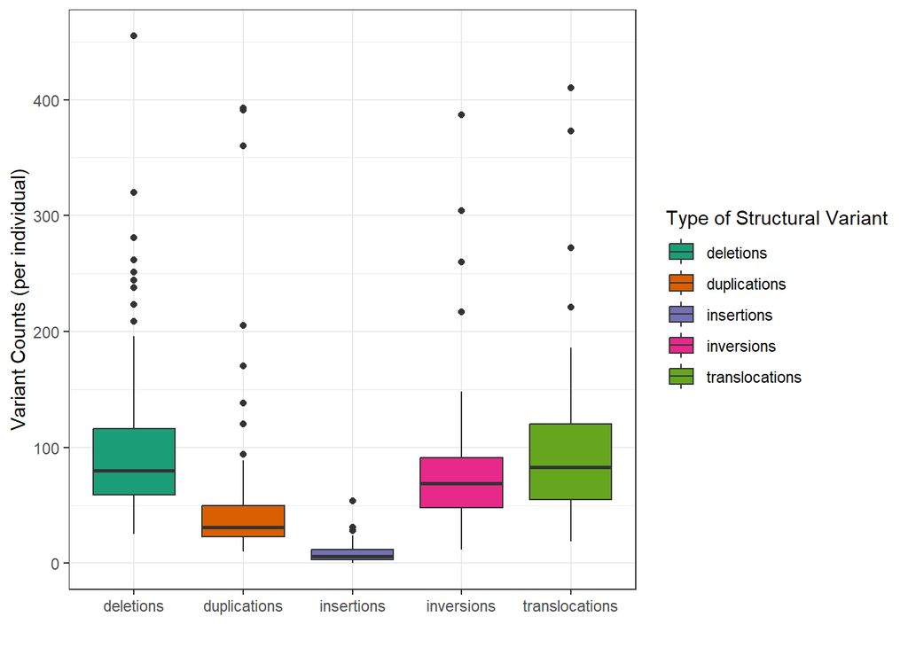

```r
# ANSWER 1.1

# packages for plotting
library(ggplot2)
library(viridis)
library(tidyr)

# structure data in form needed for ggplot
sv_plot = sv |>
          tibble::rownames_to_column("id") |>
          tidyr::pivot_longer(data = _,
                              cols = !id,
                            #  id_cols = "id",
                              names_to = "group",
                              values_to = "counts")

sv_plot |>
  ggplot(aes(x=group, y= counts, fill = group)) +
  geom_boxplot() +
  theme_bw() +
  labs(x = " ", y = "Variant Counts (per individual)") +
  scale_fill_brewer(name = "Type of Structural Variant", palette = "Dark2")
```

**Answer (1.1):** Yes, all distributions of the counts of structural variants appear to have outliers. All of these outliers are above the mean, indicating the distributions are all right skewed.

**QUESTION 1.2** Which SV types are most frequent? Least frequent?

```r
# ANSWER 1.2
sort(colSums(sv), decreasing = T) # total number of each SV
```

```
##      deletions translocations     inversions   duplications     insertions
##          10186           9851           8042           5099            878
```

```r
sort(colMeans(sv), decreasing = T) # average number of each svc
```

```
##      deletions translocations     inversions   duplications     insertions
##     100.851485      97.534653      79.623762      50.485149       8.693069
```

```r
sort(apply(sv, 2, median), decreasing = T) # median number of each sv
```

```
## translocations      deletions     inversions   duplications     insertions
##             83             80             69             31              6
```

**Answer (1.2):** Deletions and translations are the most frequent type of structural variant (mean = 100.85, 97.53 respectively) and insertions are the least frequent type of structural variant (mean = 8.69).

### Question 2: Is this normal?

Some analyses are contingent on distributional assumptions. For example, they may assume values are normally distributed. We can test the assumption that a sample is normally distributed with a QQ plot:

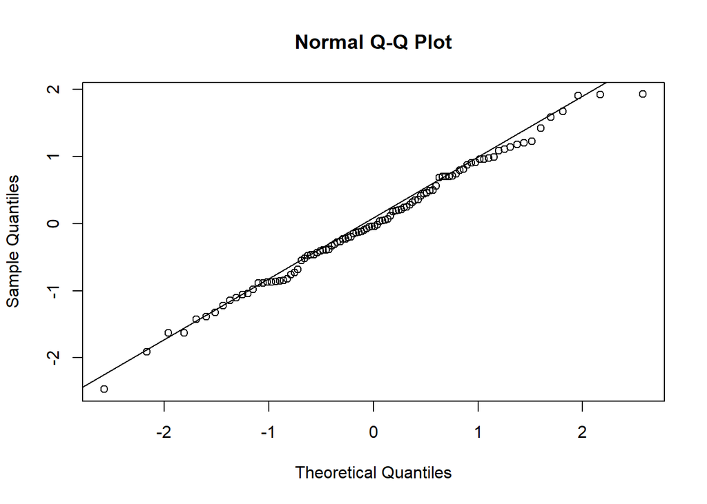

```r
set.seed(124)
x=rnorm(100)
qqnorm( x )
qqline( x )
```

**QUESTION 2.1** Generate a QQ plot to evaluate the assumption that deletions are normally distributed. Are deletions normally distributed?

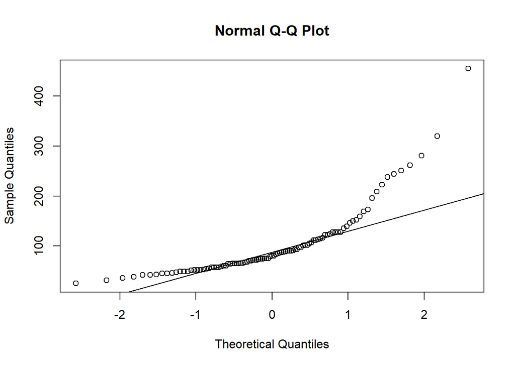

```r
# ANSWER 2.1
{
qqnorm(sv[, "deletions"])
qqline(sv[, "deletions"])
}
```

**Answer (2.1):** From the above plot, it does not appear that the number of deletion variants is normally distributed. The empirical quantiles of the count of deletions are not close to the expected quantiles for a normal distribution (i.e., near the line). In particular, at theoretical standard normal quantities <-1 and >1, the points in the above Q-Q plot are much higher than the line.

### Question 3: It’s not normal

Data that are not normally distributed can be coerced towards a normal distribution by transforming the data. How could you transform the distribution of deletions so that it’s closer to normal?

**QUESTION 3.1** Replot the QQ plot after performing a log transformation to see what effect your transformation had. Did this transformation make the sample more similar to a normal distribution?

**Note: leave the data as their original counts for the rest of the questions. Just transform for this question.**

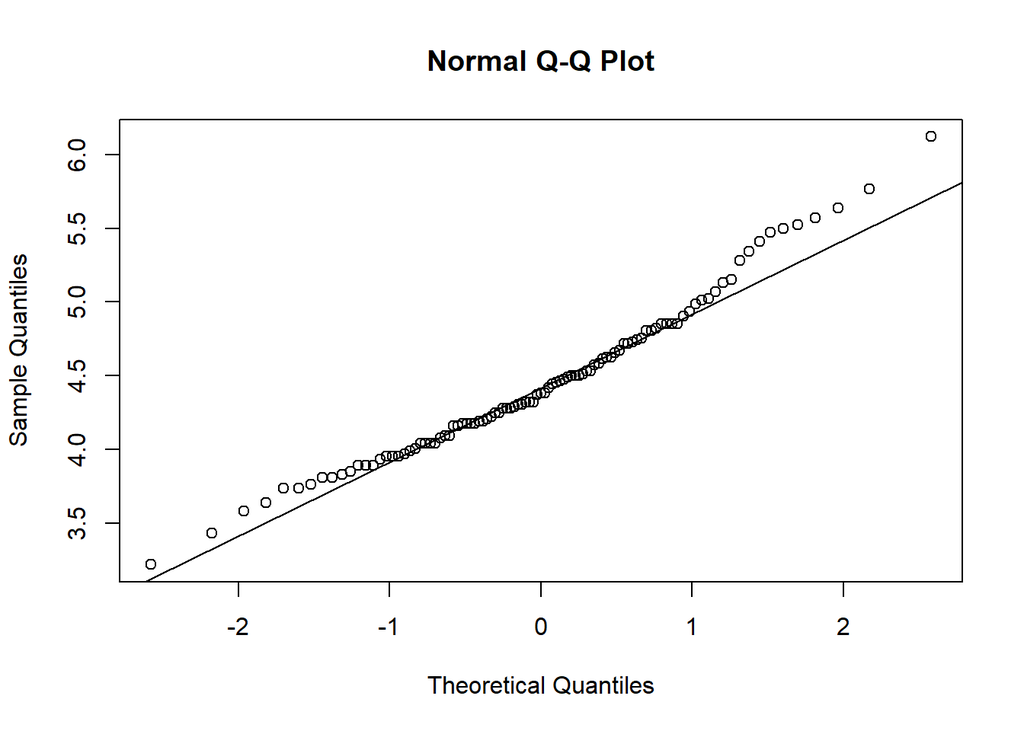

```r
# ANSWER 3.1
log_del = log(sv[, "deletions"])
{
qqnorm(log_del)
qqline(log_del)
}
```

**Answer (3.1):** Yes, the log transformation made the distribution of the number of deletion variants per individual more similar to a normal distribution.

### Question 4: We belong together

Structural variations arise from DNA damage that is not repaired. By analyzing tumor genomes, we can figure out the kind of DNA damage that occurred by studying the patterns of SVs.

The null model is that there is no relationship between the number of any type of SV. Alternatively, there might be an association between some of the SV types, suggesting something in common about their etiology.

**QUESTION 4.1** Calculate pairwise correlation between all five types of SV and plot the resulting correlation coefficients as a heat map. Try both Pearson correlation (the parametric default method in R) and non-parametric Spearman rank correlation, to see if it matters.

*Hint for plotting a simple correlation heatmap, where the matrix X contains the values to plot in the heatmap:*

[figure not shown]

```r
# calculate pairwise pearson correlation
X = round(cor(sv), digits = 2)

XTidy = melt( X, value.name="val", varnames = c("x", "y") )

ggplot(XTidy, aes( x, y ) ) +
     geom_tile( aes( fill = val ) ) +
     geom_text( aes( label = val ) ) +
  labs(x = "", y = " " , title = "Correlation (Spearman) between counts of different variants") +
  scale_fill_viridis(name = "Pearson \n (r^2)", option = "D")
```

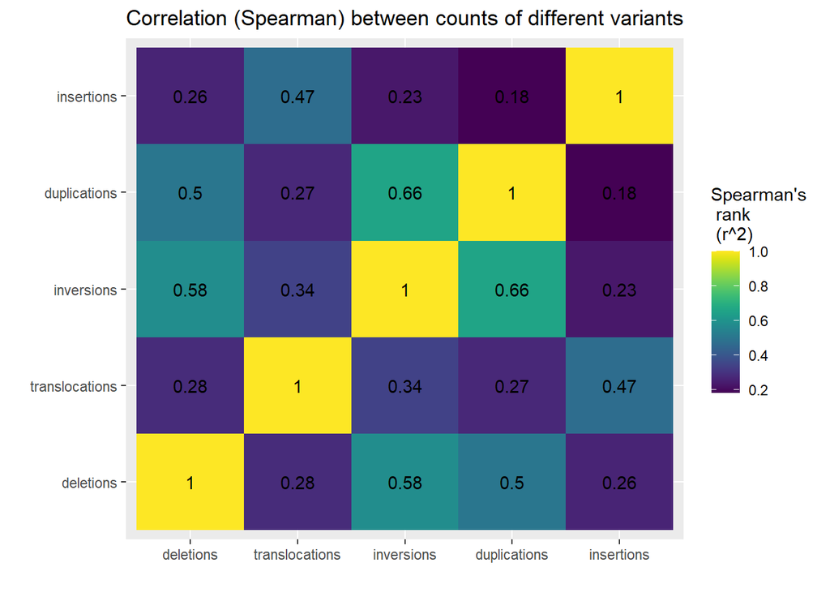

```r
# calculate spearman rank correlation
X = round(cor(sv, method = "spearman"), digits = 2)

XTidy = melt( X, value.name="val", varnames = c("x", "y") )

ggplot(XTidy, aes( x, y ) ) +
     geom_tile( aes( fill = val ) ) +
     geom_text( aes( label = val ) ) +
    labs(x = "", y = " " , title = "Correlation (Spearman) between counts of different variants") +
    scale_fill_viridis(name = "Spearman's \n rank \n (r^2)", option = "D")
```

**QUESTION 4.2** Which types of SV are most strongly correlated with each other? Without formal testing, do the correlation data support the null model, or is there reason to investigate an alternative model? Which pairs of SV are most likely to occur in similar counts?

```r
# ANSWER 4.2
```

**Answer (4.1):** Duplications and inversions are the types of structural variants that most strongly correlated with each other.

**QUESTION 4.3 (BONUS)**: Why are the correlation values so different when comparing Spearman rank correlation to Pearson correlation? What might be driving these differences? Does it matter?

```r
# ANSWER 4.3
```

**Answer (4.3):** The observed correlation values are so different due to the properties of the structural variant count distributions. For instance, unlike Spearman’s rank, the Pearson correlation method assumes that data is normally distributed data. However, as shown in questions 1 & 2, this assumption of normally distributed data is inconsistent with the distribution we observe for the number of deletions and, most likely, for all other structural variants. Additionally, outliers in data are likely to disproportionally impact the estimated correlation when we apply Pearson’s versus Spearman’s methods. Thus, the fact that we observe many outliers in the boxplots in question 1 suggests that Pearson’s and Spearman’s rank correlation methods would produce different results.

Overall, the factors likely to be driving the differences between the two estimated correlations are the right skew and count-based nature of the data and the fact that some individuals have atypically large counts of some structural variants (i.e., outliers).

However, this difference may not matter, or at least matter less, if all the count data is log transformed to be closer to a normal distribution before these correlations are estimated.

### Question 5: Outliers of interest

Let’s drill down on two contrasting pairs of SVs:

1. duplications and inversions
2. deletions and inversions

**QUESTION 5.1** Create two scatter plots: duplications vs inversions, and deletions vs. inversions. Based on question 4, we’d expect the counts of these SVs to be somewhat correlated with each other. Does this hold up? Are there samples that are outliers from the linear trend in these comparisons?

Samples that deviate from a relationship like this might be of particular interest.

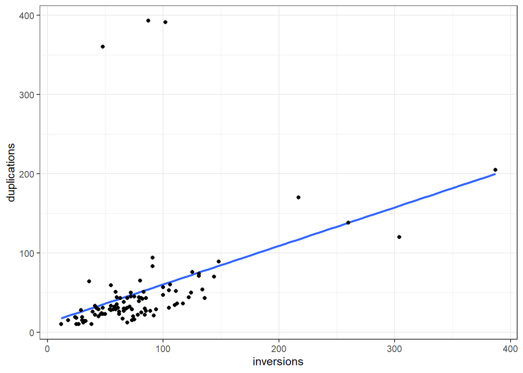

```r
# ANSWER 5.1
sv |>
  ggplot(aes(x=inversions, y=duplications)) +
  geom_smooth(method = "lm", se = FALSE, formula = y~x) +
  geom_point() +
  theme_bw()
```

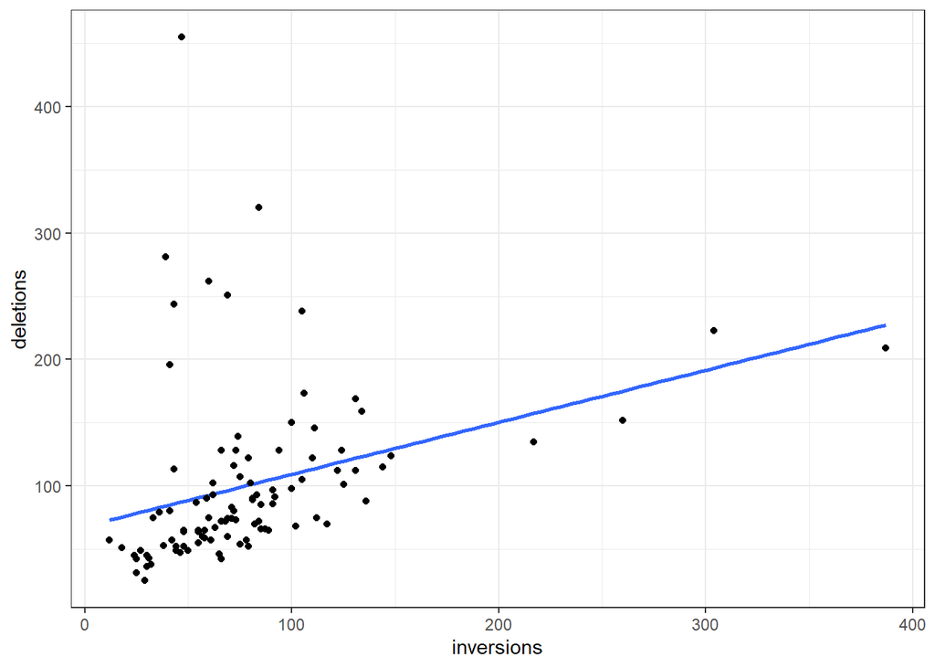

```r
sv |>
  ggplot(aes(x=inversions, y =deletions)) +
  geom_smooth(method = "lm", se = FALSE, formula = y~x) +
  geom_point() +
  theme_bw()
```

**Answer (5.1):** From the above two graphs, the assumption that the numbers of mutations counted in each individual are somewhat correlated across structural variant types appears to hold.

However, there are some outliers to this trend. In the first graph, we can see some individuals in the top left have a relatively small number of inversions (<~110) but a high number of duplication mutations (>350). Additionally, in the second graph, we can see that some individuals (top left) in this study have a high number of deletion mutations (>200) despite only having a relatively low number of inversions (<100).

### Question 6: Why the duplicates? Why the duplicates?

Let’s drill down on the duplications. Look at your plot comparing the number of duplications to the number of inversions. Note that there are three samples that have far more duplications than any other sample, and four samples that have both a large number of inversions *and* a large (though not the highest) number of duplications. Looking at this plot, we might wonder if there is something special about the three samples that have a lot of duplications but not a lot of inversions.

The *mut* matrix that you loaded contains one row for each sample and one column for each of 15 genes, with a TRUE value if there is a biallelic inactivation of that gene in that sample.

**QUESTION 6.1** We’ll test the hypothesis that tumors with a particular gene inactivation acquire a lot more duplications than tumors lacking that inactivation. Test this hypothesis by performing a Wilcoxon test comparing the number of duplicates in tumors with *vs.* without mutation in each gene. Create a barplot of -log10( *p* ) and nominate the strongest hit as worthy of further investigation.

```r
# ANSWER 6.1

# Initialize a vector to store p-values from the Wilcoxon tests
test_pval = vector()

# Loop over each gene
for(gene_id in 1:ncol(mut)){

  # Select rows (samples) with a biallelic inactivation for the current gene
  with_mut = mut[, gene_id]

  # Perform Wilcoxon test
  test_res = wilcox.test(
    x = sv[with_mut, "duplications"], # Duplications in samples with gene inactivation
    y = sv[!with_mut, "duplications"], # Duplications in samples without gene inactivation
    #alternative = "greater" # Hypothesis: tumors with gene inactivation have more duplications
  )

  # Print the results of the Wilcoxon test for each gene
  print(test_res)

  # Store the p-value of the test for each gene
  test_pval[gene_id] = test_res$p.value
}
```

```
##
##  Wilcoxon rank sum test with continuity correction
##
## data:  sv[with_mut, "duplications"] and sv[!with_mut, "duplications"]
## W = 458, p-value = 0.08561
## alternative hypothesis: true location shift is not equal to 0
##
##
##  Wilcoxon rank sum test with continuity correction
##
## data:  sv[with_mut, "duplications"] and sv[!with_mut, "duplications"]
## W = 75, p-value = 0.5666
## alternative hypothesis: true location shift is not equal to 0
##
##
##  Wilcoxon rank sum test with continuity correction
##
## data:  sv[with_mut, "duplications"] and sv[!with_mut, "duplications"]
## W = 215.5, p-value = 0.3213
## alternative hypothesis: true location shift is not equal to 0
##
##
##  Wilcoxon rank sum test with continuity correction
##
## data:  sv[with_mut, "duplications"] and sv[!with_mut, "duplications"]
## W = 1581.5, p-value = 0.03357
## alternative hypothesis: true location shift is not equal to 0
##
##
##  Wilcoxon rank sum test with continuity correction
##
## data:  sv[with_mut, "duplications"] and sv[!with_mut, "duplications"]
## W = 1422.5, p-value = 0.07383
## alternative hypothesis: true location shift is not equal to 0
##
##
##  Wilcoxon rank sum test with continuity correction
##
## data:  sv[with_mut, "duplications"] and sv[!with_mut, "duplications"]
## W = 414, p-value = 0.2095
```

[output cut: 49 more lines]

```
## alternative hypothesis: true location shift is not equal to 0
##
##
##  Wilcoxon rank sum test with continuity correction
##
## data:  sv[with_mut, "duplications"] and sv[!with_mut, "duplications"]
## W = 294, p-value = 0.003368
## alternative hypothesis: true location shift is not equal to 0
##
##
##  Wilcoxon rank sum test with continuity correction
##
## data:  sv[with_mut, "duplications"] and sv[!with_mut, "duplications"]
## W = 24, p-value = 0.06924
## alternative hypothesis: true location shift is not equal to 0
```

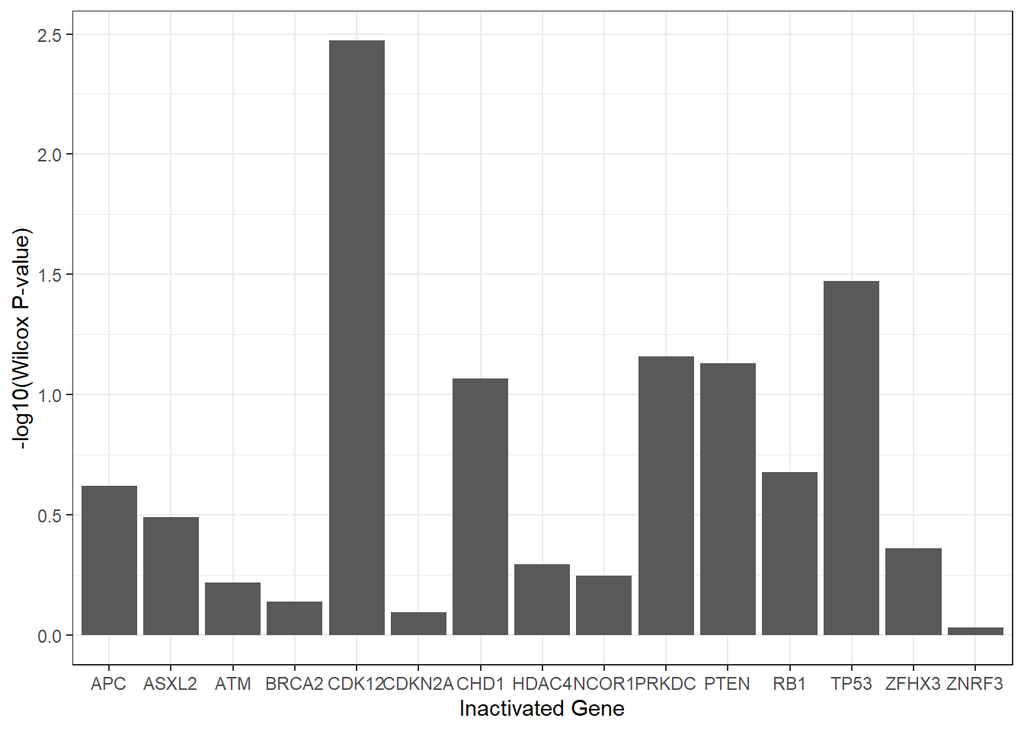

```r
data.frame(wilcox_pval = test_pval,
           gene = as.factor(names(mut))) |>
  dplyr::mutate(log_pval = -log(wilcox_pval, base = 10)) |>
  ggplot(aes(group = gene, x= gene, y=log_pval)) +
  geom_bar(stat = "identity") +
  labs(x = "Inactivated Gene",
       y = "-log10(Wilcox P-value)") +
  theme_bw()
```

**Answer (6.1):** The most significant gene where gene inactivation is associated with an increased number of duplication mutations is CDK12; this strongest hit is thus worthy of further investigation.

### Question 7: Why so many deletions?

Now let’s take a close look at deletions. Look at the scatter plot you made comparing inversions *vs* deletions. There tends to be a linear relationship, even for samples with large numbers of inversions, but there is a set of samples that have lots of deletions but not a lot of inversions.

**QUESTION 7.1** You might hypothesize that tumors that have inactivated a DNA repair gene harbor a lot more deletions than normal tumors. Test this hypothesis by performing a Wilcox test comparing the number of deletions in tumors with *vs.* without mutation in each gene. This time, instead of a barplot, create a volcano plot to compare the difference in means (as the effect) vs. the -log10(*p*) as the statistical strength. Does this analysis nominate any gene as associated with large numbers of deletions?

```r
# ANSWER 7.1
test_pval = vector()
test_effect_size = vector()

for(gene_id in 1:ncol(mut)){

  with_mut = mut[, gene_id]

  test_res =
    wilcox.test(x = sv[with_mut, "deletions"],
              y = sv[!with_mut, "deletions"],
  #                alternative = "greater"
              )

  print(test_res)

  test_pval[gene_id] = test_res$p.value
  test_effect_size[gene_id] = mean(sv[with_mut, "deletions"])/
                              mean(sv[!with_mut, "deletions"])

}
```

```
##
##  Wilcoxon rank sum test with continuity correction
##
## data:  sv[with_mut, "deletions"] and sv[!with_mut, "deletions"]
## W = 465, p-value = 0.06996
## alternative hypothesis: true location shift is not equal to 0
##
##
##  Wilcoxon rank sum test with continuity correction
##
## data:  sv[with_mut, "deletions"] and sv[!with_mut, "deletions"]
## W = 121.5, p-value = 0.5917
## alternative hypothesis: true location shift is not equal to 0
##
##
##  Wilcoxon rank sum test with continuity correction
##
## data:  sv[with_mut, "deletions"] and sv[!with_mut, "deletions"]
## W = 156, p-value = 0.06483
## alternative hypothesis: true location shift is not equal to 0
##
##
##  Wilcoxon rank sum test with continuity correction
##
## data:  sv[with_mut, "deletions"] and sv[!with_mut, "deletions"]
## W = 1391.5, p-value = 0.4061
## alternative hypothesis: true location shift is not equal to 0
##
##
##  Wilcoxon rank sum test with continuity correction
##
## data:  sv[with_mut, "deletions"] and sv[!with_mut, "deletions"]
## W = 1438.5, p-value = 0.05735
## alternative hypothesis: true location shift is not equal to 0
##
##
##  Wilcoxon rank sum test with continuity correction
##
## data:  sv[with_mut, "deletions"] and sv[!with_mut, "deletions"]
## W = 571.5, p-value = 0.6977
```

[output cut: 49 more lines]

```
## alternative hypothesis: true location shift is not equal to 0
##
##
##  Wilcoxon rank sum test with continuity correction
##
## data:  sv[with_mut, "deletions"] and sv[!with_mut, "deletions"]
## W = 100, p-value = 0.3522
## alternative hypothesis: true location shift is not equal to 0
##
##
##  Wilcoxon rank sum test with continuity correction
##
## data:  sv[with_mut, "deletions"] and sv[!with_mut, "deletions"]
## W = 50, p-value = 0.237
## alternative hypothesis: true location shift is not equal to 0
```

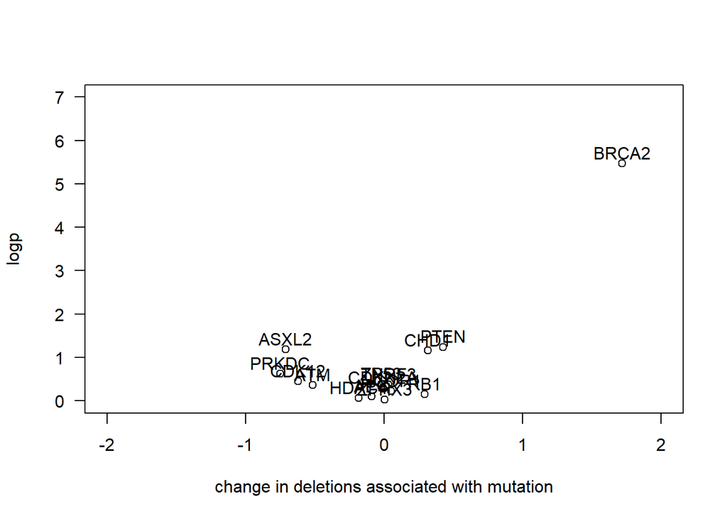

```r
# convert effect size and pvalues into plotting measurements of
# log fold change and - log 10 (p-value)
effect_size =  log2(test_effect_size)
logp = -log(test_pval, base = 10)

gene_names = dimnames(mut)[[2]]
plot( effect_size, logp, las=1,
      xlim=c(-2,2),
      ylim=c(0,7),
      xlab="change in deletions associated with mutation")
text( effect_size, logp + 0.25, gene_names ) # show gene names on the plot
```

**Answer (7.1):** Yes, the above volcano plot nominates inactivation of BRAC2 as associated with large numbers of deletions.

### **QUESTION 7.2 (BONUS)**

Re-run the test you performed in problem 7.1, using a *t test* rather than a Wilcoxon test. Explain why these tests have different performance and produce different results. Discuss the difference between ranking candidates based on *P* value and based on a combination of *P* value and effect size.

```r
test_pval = vector()
test_effect_size = vector()

for(gene_id in 1:ncol(mut)){

  with_mut = mut[, gene_id]

  test_res =
    t.test(x = sv[with_mut, "deletions"],
           y = sv[!with_mut, "deletions"],
           #alternative = "greater"
           )

  print(test_res)

  test_pval[gene_id] = test_res$p.value
  test_effect_size[gene_id] = test_res$estimate[1]/test_res$estimate[2]

}
```

```
##
##  Welch Two Sample t-test
##
## data:  sv[with_mut, "deletions"] and sv[!with_mut, "deletions"]
## t = 1.174, df = 7.6777, p-value = 0.2755
## alternative hypothesis: true difference in means is not equal to 0
## 95 percent confidence interval:
##  -23.89277  72.71648
## sample estimates:
## mean of x mean of y
## 123.57143  99.15957
##
##
##  Welch Two Sample t-test
##
## data:  sv[with_mut, "deletions"] and sv[!with_mut, "deletions"]
## t = 0.10581, df = 1.0808, p-value = 0.9319
## alternative hypothesis: true difference in means is not equal to 0
## 95 percent confidence interval:
##  -371.4920  378.9364
## sample estimates:
## mean of x mean of y
##  104.5000  100.7778
##
##
##  Welch Two Sample t-test
##
## data:  sv[with_mut, "deletions"] and sv[!with_mut, "deletions"]
## t = -3.6668, df = 14.518, p-value = 0.002404
## alternative hypothesis: true difference in means is not equal to 0
## 95 percent confidence interval:
##  -63.42134 -16.70849
## sample estimates:
## mean of x mean of y
##  63.16667 103.23158
##
##
##  Welch Two Sample t-test
##
## data:  sv[with_mut, "deletions"] and sv[!with_mut, "deletions"]
```

[output cut: 124 more lines]

```
## sample estimates:
## mean of x mean of y
##  66.33333 101.90816
##
##
##  Welch Two Sample t-test
##
## data:  sv[with_mut, "deletions"] and sv[!with_mut, "deletions"]
## t = -5.344, df = 20.391, p-value = 2.941e-05
## alternative hypothesis: true difference in means is not equal to 0
## 95 percent confidence interval:
##  -57.21577 -25.11756
## sample estimates:
## mean of x mean of y
##   60.5000  101.6667
```

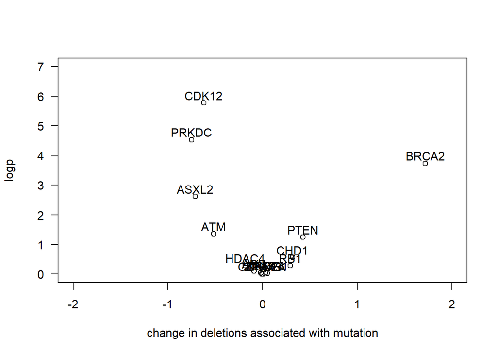

```r
# convert effect size and pvalues into plotting measurements of
# log fold change and - log 10 (p-value)
effect_size =  log2(test_effect_size)
logp = -log(test_pval, base = 10)

gene_names = dimnames(mut)[[2]]

plot( effect_size, logp, las=1,
      xlim=c(-2,2),
      ylim=c(0,7),
      xlab="change in deletions associated with mutation")
text( effect_size, logp + 0.25, gene_names ) # show gene names on the plot
```

The difference between ranking candidates on p-value alone, rather than p-value and effect size, is that this can sometimes prioritize different candidates for follow-up. When we only use p-values to rank candidates, we may follow up on candidates who don’t have the largest effect sizes. This scenario may occur because less variability across samples can also make p-values more significant for the same observed effect size. Thus, even though such candidates are the most statistically significant, they may not be the most biologically or clinically significant candidates because their effect may be smaller than candidates with less significant p-values but greater variability among patients.